# Introduction to Simulation Modeling

2020-07-20 08:53:15

## Science needs data

[figure not shown]

dilbert.com

## Experimental studies

- The approach used in almost all bench/lab sciences.
- Clinical trials in Public Health and Medicine.
- Potentially most powerful because we have most control.
- Not always possible.

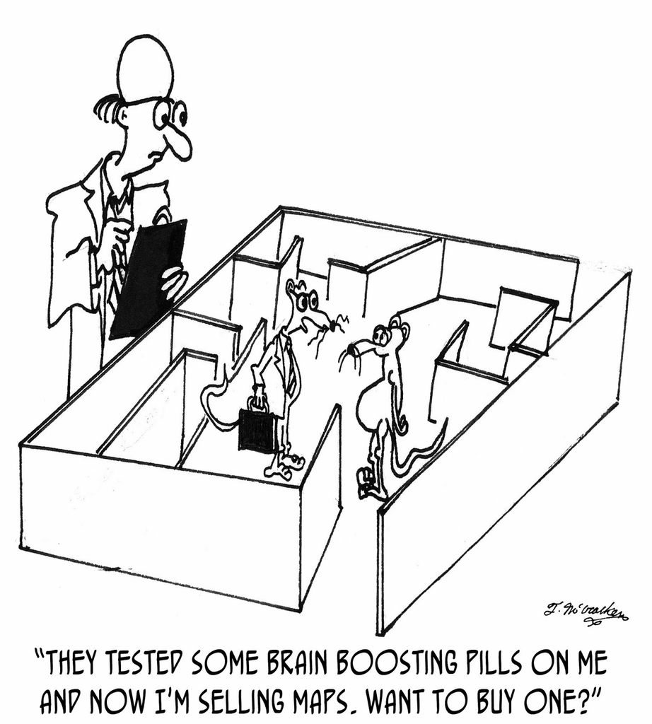

## Observational studies

- Widely used in Public Health and other areas (e.g. Medicine, Sociology, Geology).
- Not as powerful as experimental studies.
- Often the only option.

[figure not shown]

Jim Borgman

## Simulation/modeling studies

- Computer models can represent a real system.
- Simulated data is not as good as real data.
- Often the only option.

[figure not shown]

xkcd.com

## Modeling definition

- The term **modeling** usually means (in science) the description and analysis of a system using mathematical or computational models.

[figure not shown]

- Many different types of modeling approaches exist. Simulation models are one type (with many subtypes).

## A way to classify models

- **Phenomenological/non-mechanistic/(statistical) models**
  - Look at patterns in data
  - Do not describe mechanisms leading to the data
- **Mechanistic/process/simulation models**
  - Try to represent simplified versions of mechanisms
  - Can be used with and without data

## Phenomenological models

- You might be familiar with statistical models (that includes Machine Learning, AI, Deep Learning,…).
- Most of those models are phenomenological/non-mechanistic (and static).
- Those models are used extensively in all areas of science.
- The main goal of these models is to understand data/patterns and make predictions.

[figure not shown]

xkcd.com

## Non-mechanistic model example

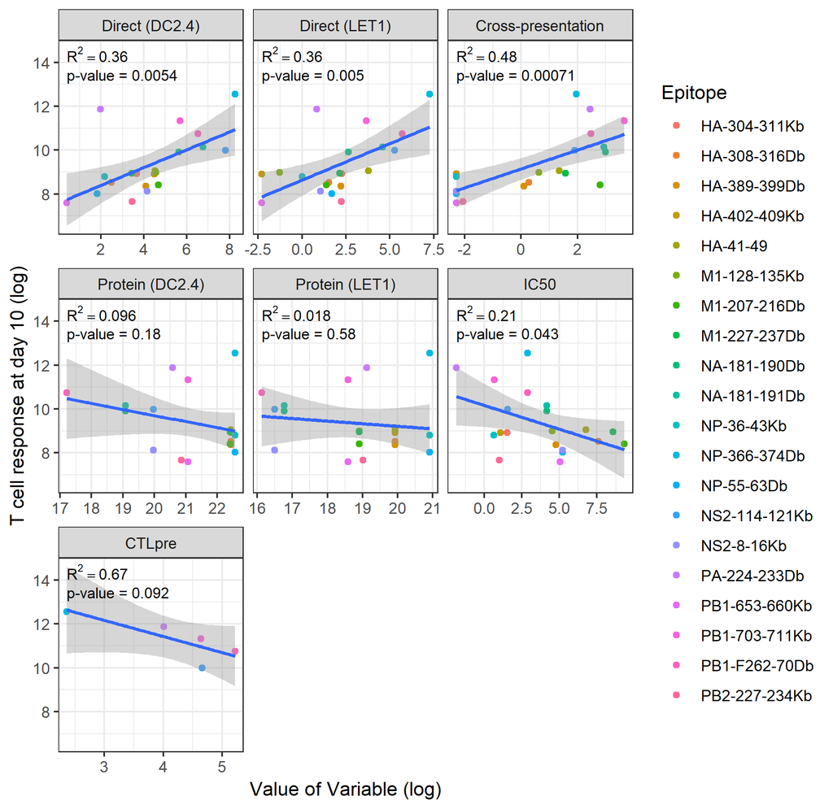

Wu et al 2019 Nature Communications.

## Non-mechanistic models - Advantages

- Finding correlations/patterns is (relatively) simple.
- Some models are very good at predicting (e.g. Netflix, Google Translate).
- Sometimes we can go from correlation to causation.
- We don’t need to understand all the underlying mechanisms to get actionable insights.

[figure not shown]

dilbert.com

## Non-mechanistic models - Disadvantages

- The jump from correlation to causation is always tricky (bias/confounding/systematic errors).
- Even if we can assume a causal relation, we do not gain a lot of mechanistic insights or deep understanding of the system.

## Mechanistic models

- We formulate explicit mechanisms/processes driving the system dynamics.
- This is done using mathematical equations (often ordinary differential equations), or computer rules.
- Also called **systems/dynamic(al)/ (micro)simulation/process/ mathematical/ODE/… models**.

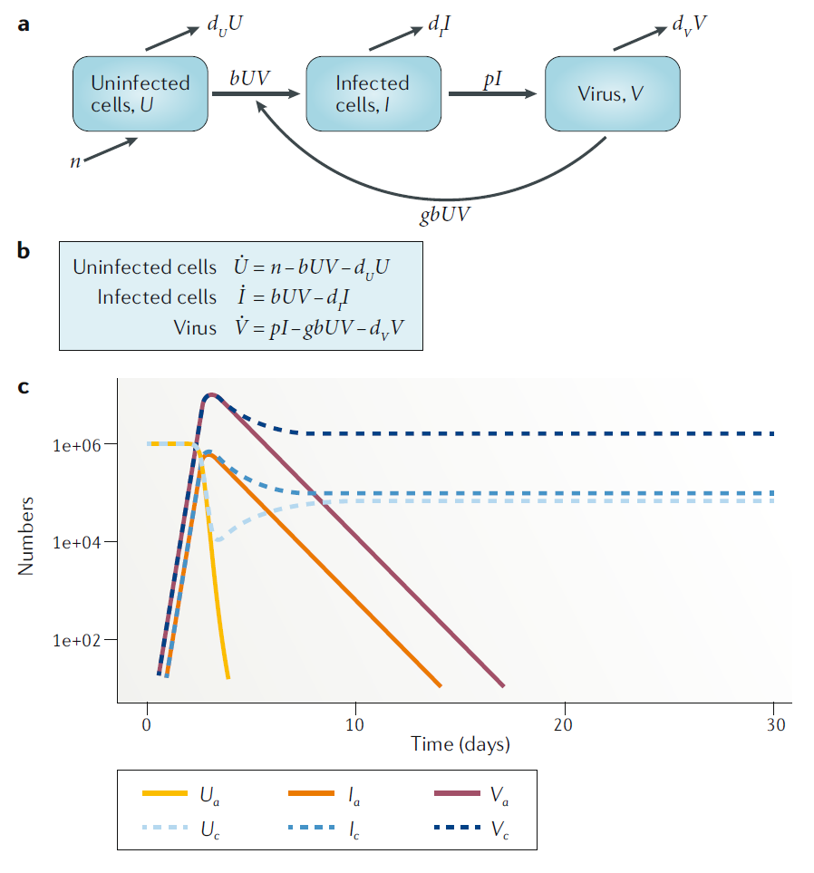

## Mechanistic model example

\[ \begin{aligned} \dot V & = rV-kVT^*\\ \dot P & = fV - dP \\ \dot T & = -aPT \\ \dot T^* & = aPT + gT^* \end{aligned} \]

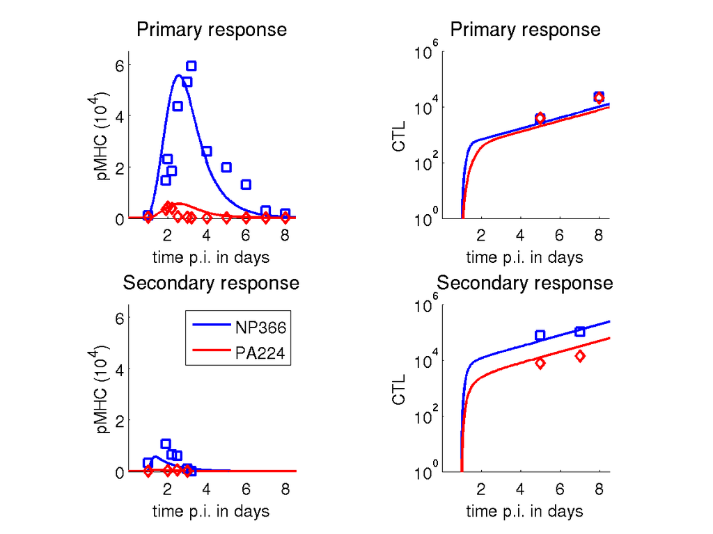

Handel & Antia 2008 J Vir

## Mechanistic models - Advantages

- We get a potentially deeper, mechanistic understanding of the system.
- We know exactly how each component affects the others in our model.

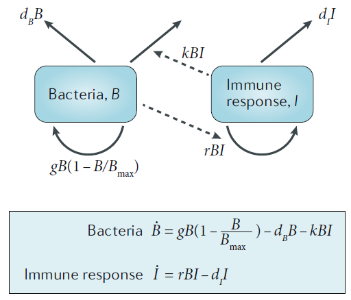

## Mechanistic models - Disadvantages

- We need to know (or assume) something about the mechanisms driving our system to build a mechanistic model.
- If our assumptions/model are wrong, the “insights” we gain from the model are spurious.

[figure not shown]

## Non-mechanistic vs Mechanistic models

- Non-mechanistic models (e.g. regression models, machine learning) are useful to see if we can find patterns in our data and possibly predict, without necessarily trying to understand the mechanisms.
- Mechanistic models are useful if we want to study the mechanism(s) by which observed patterns arise.

**Ideally, you want to have both in your ‘toolbox’.**

## Simulation models

- We will focus on **mechanistic simulation models.**
- The hallmark of such models is that they explicitly (generally in a simplified manner) model processes occuring in a system.

## Simulation modeling uses

- Weather forecasting.
- Simulations of a power plant or other man-made system.
- Predicting the economy.
- Infectious disease transmission.
- Immune response modeling.
- …

[figure not shown]

www.gocomics.com/nonsequitur

## Real-world examples

Using a TB model to explore/predict cytokine-based interventions (Wigginton and Kirschner, 2001 J Imm).

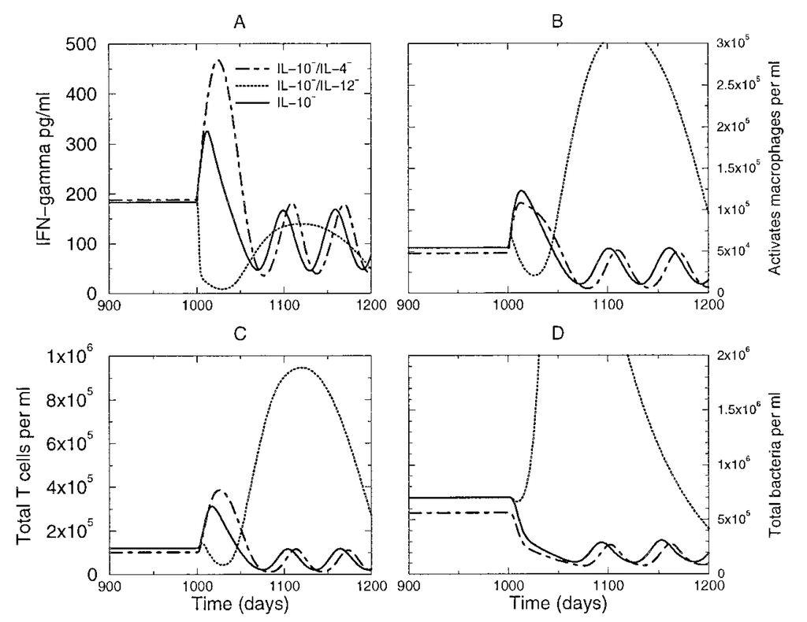

## Real-world examples

Targeted antiviral prophylaxis against an influenza pandemic (Germann et al 2006 PNAS).

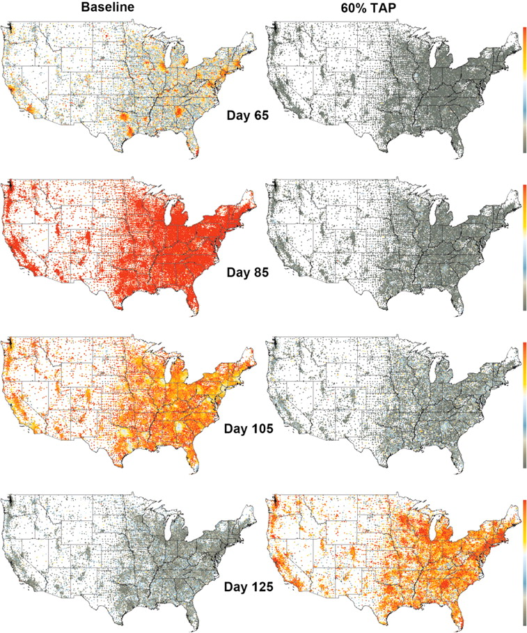

## Within-host and between-host modeling

| Within-host/individual level | Between-host/population level |
| --- | --- |
| Spread inside a host (virology, microbiology, immunology) | Spread on the population level (ecology, epidemiology) |
| Populations of pathogens & immune response components | Populations of hosts (humans, animals) |
| Acute/Persistent (e.g. Flu/TB) | Epidemic/Endemic (e.g. Flu/TB) |
| Usually (but not always) explicit modeling of pathogen | Often, but not always, no explicit modeling of pathogen |

The same types of simulation models are often used on both scales.

## Population level modeling history

- 1766 - Bernoulli “An attempt at a new analysis of the mortality caused by smallpox and of the advantages of inoculation to prevent it” (see Bernoulli & Blower 2004 Rev Med Vir)
- 1911 – Ross “The Prevention of Malaria”
- 1920s – Lotka & Volterra “Predator-Prey Models”
- 1926/27 - McKendrick & Kermack “Epidemic/outbreak models”
- 1970s/80s – Anderson & May
- Lot’s of activity since then
- See also Bacaër 2011 “A Short History of Mathematical Population Dynamics”

## Within-host modeling history

- The field of within-host modeling is somewhat recent, with early attempts in the 70s and 80s and a strong increase since then.
- HIV garnered a lot of attention starting in the late 80s, some influential work happened in the early 90s.
- Overall, within-host models are still less advanced compared to between-host modeling, but it’s rapidly growing.